# Activity

Vedanti

26/06/2020

## READING THE FILE

What is mean total number of steps taken per day? For this part of the assignment, you can ignore the missing values in the dataset.

Calculate the total number of steps taken per day If you do not understand the difference between a histogram and a barplot, research the difference between them. Make a histogram of the total number of steps taken each day Calculate and report the mean and median of the total number of steps taken per day

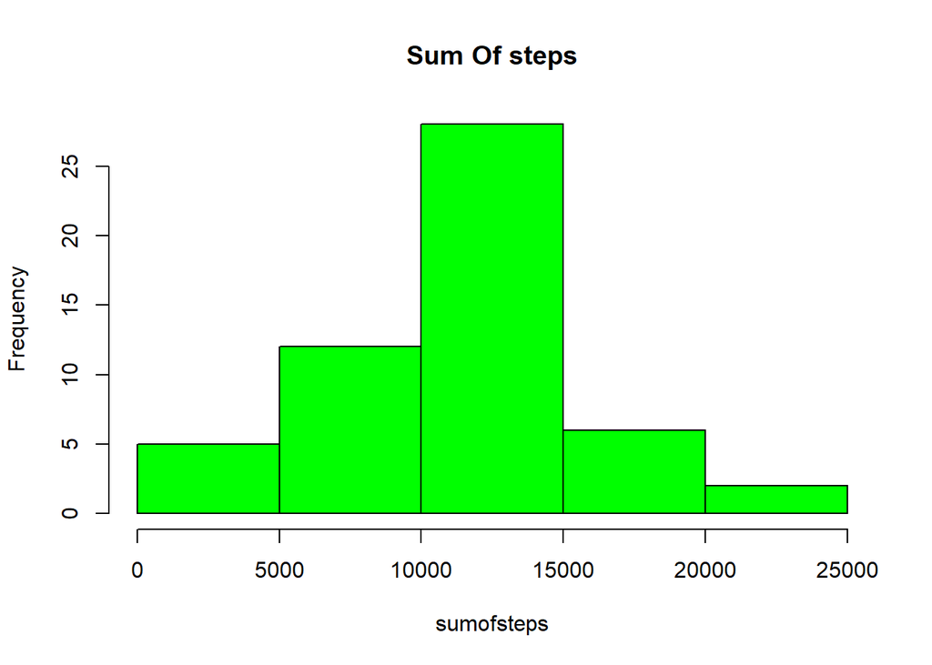

```r
df <- read.csv( "activity.csv")
sumofsteps <- tapply(df$steps, df$date, sum)
hist(sumofsteps, col = "green", main = "Sum Of steps")
```

```r
summary(sumofsteps)
```

```
##    Min. 1st Qu.  Median    Mean 3rd Qu.    Max.    NA's
##      41    8841   10765   10766   13294   21194       8
```

What is the average daily activity pattern? Make a time series plot (i.e. type = “l”) of the 5-minute interval (x-axis) and the average number of steps taken, averaged across all days (y-axis) Which 5-minute interval, on average across all the days in the dataset, contains the maximum number of steps?

```r
library(dplyr)
meanofsteps<- df %>% group_by(interval)  %>% summarize(meansteps= mean(steps, na.rm = TRUE))
```

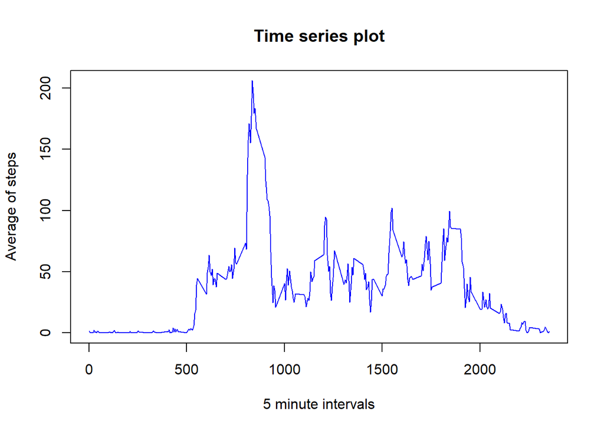

```r
plot(meanofsteps, type="l", col="blue", xlab="5 minute intervals", ylab ="Average of steps", main = "Time series plot")
```

```r
meanofsteps$interval[which.max(meanofsteps$meansteps)]
```

```
## [1] 835
```

```r
max(meanofsteps$meansteps)
```

```
## [1] 206.1698
```

```r
summary(df)
```

```
##      steps            date              interval
##  Min.   :  0.00   Length:17568       Min.   :   0.0
##  1st Qu.:  0.00   Class :character   1st Qu.: 588.8
##  Median :  0.00   Mode  :character   Median :1177.5
##  Mean   : 37.38                      Mean   :1177.5
##  3rd Qu.: 12.00                      3rd Qu.:1766.2
##  Max.   :806.00                      Max.   :2355.0
##  NA's   :2304
```

Imputing missing values Note that there are a number of days/intervals where there are missing values (coded as NA). The presence of missing days may introduce bias into some calculations or summaries of the data.